# Hackathon_infinity

Shameless

22 giugno 2018

Autori dell’analisi: Francesco Gabellini Daniel Sako Marco Pedini In occasione dell’ Hackathon sulla churn analysis organizzato da Infinity.

```r
library(tidyverse)
library(lubridate)
library(ade4)
library(caret)
library(rpart)
library(DMwR)
library(pROC)
library(randomForest)
```

```r
library(rpart.plot)
set.seed(1234)
```

Carico Dataset

```r
transactions_test <- read.delim("C:/Users/SuperOrso1/Desktop/Hackaton_finale/transactions_test.csv")
transactions_training <- read.delim("C:/Users/SuperOrso1/Desktop/Hackaton_finale/transactions_training.csv")
user_logs <- read.delim("C:/Users/SuperOrso1/Desktop/Hackaton_finale/user_logs.csv")
metadata <- read.delim("C:/Users/SuperOrso1/Desktop/Hackaton_finale/metadata.csv")
```

Unisco test e set

```r
transaction_tt <- rbind.data.frame(transactions_training,transactions_test )
```

Content_id solo prime 8

```r
metadata$content_id_8 <-substr(metadata$content_id, start = 1, stop = 8)
user_logs$content_id_8 <-substr(user_logs$content_id, start = 1, stop = 8)
```

faccio merge

```r
user_logs_metadata <- merge(user_logs,metadata,by="content_id_8", all.x = TRUE)
user_logs_metadata <- user_logs_metadata[-1,]
```

Creo variabile per periodo con lubridate

```r
user_logs_metadata$fruition_date <- ymd(user_logs_metadata$fruition_date)
transaction_tt$registration_date <- ymd(transaction_tt$registration_date)
transaction_tt$transaction_date <- ymd(transaction_tt$transaction_date )
transaction_tt$expire_date <- ymd(transaction_tt$expire_date )
```

per mese

```r
transaction_tt$month <- month(transaction_tt$transaction_date)
user_logs_metadata$month <- month(user_logs_metadata$fruition_date)
```

Dummy variabil:

channel

```r
df_cat <- as.data.frame(user_logs_metadata$channel)
dummy_channel <- acm.disjonctif(df_cat)
user_logs_metadata <- cbind.data.frame(user_logs_metadata,dummy_channel)
user_logs_metadata$`user_logs_metadata$channel.`<-NULL
rm(dummy_channel)
```

Is_downloaded

```r
df_cat <- as.data.frame(user_logs_metadata$is_downloaded )
dummy_dowloaded <- acm.disjonctif(df_cat)
user_logs_metadata <- cbind.data.frame(user_logs_metadata,dummy_dowloaded)
user_logs_metadata$`user_logs_metadata$is_downloaded.`<-NULL
rm(dummy_dowloaded)
```

Is_art

```r
df_cat <- as.data.frame(user_logs_metadata$is_art_film )
dummy_art_film<- acm.disjonctif(df_cat)
user_logs_metadata <- cbind.data.frame(user_logs_metadata,dummy_art_film)
user_logs_metadata$`user_logs_metadata$is_art_film.`<-NULL
rm(dummy_art_film)
```

Is_cult

```r
df_cat <- as.data.frame(user_logs_metadata$is_cult )
dummy_cult<- acm.disjonctif(df_cat)
user_logs_metadata <- cbind.data.frame(user_logs_metadata,dummy_cult)
user_logs_metadata$`user_logs_metadata$is_cult.`<-NULL
rm(dummy_cult)
```

content_type

```r
table(user_logs_metadata$content_type)
```

```
##
## INTRATTENIMENTO           MOVIE        TVSERIES
##           68355          679415         1513220
```

```r
df_cat <- as.data.frame(user_logs_metadata$content_type )
dummy_content<- acm.disjonctif(df_cat)
user_logs_metadata <- cbind.data.frame(user_logs_metadata,dummy_content)
user_logs_metadata$`user_logs_metadata$content_type.`<-NULL
rm(dummy_content)
```

genre

```r
table(user_logs_metadata$genre)
```

```
##
##          Azione Comico/Commedia    Diretta news          Dramma
##          700840          792275               0          436643
##         Factual       Game show        Magazine    Reality show
##             555              25            2500           42124
##       Reportage     Talent show       Talk show    Telegiornali
##               0            7043            2129               0
##        Thriller         Varieta
##          262877           13979
```

```r
df_cat <- as.data.frame(user_logs_metadata$genre )
dummy_genre<- acm.disjonctif(df_cat)
user_logs_metadata <- cbind.data.frame(user_logs_metadata,dummy_genre)
user_logs_metadata$`user_logs_metadata$genre.`<-NULL
user_logs_metadata$`user_logs_metadata$genre.Diretta news`<-NULL
user_logs_metadata$`user_logs_metadata$genre.Reportage`<-NULL
user_logs_metadata$`user_logs_metadata$genre.Telegiornali`<-NULL
rm(dummy_genre)
```

Tempo tra le fruiioni

```r
user_logs_metadata <- user_logs_metadata %>% arrange(user_id,fruition_date)

user_logs_metadata$fruition_date_1 <- lag(user_logs_metadata$fruition_date)
user_logs_metadata$day_span <- ymd(user_logs_metadata$fruition_date)-ymd(user_logs_metadata$fruition_date_1)
```

Metto a posto tale varaibile

```r
user_logs_metadata$day_span <- as.double(user_logs_metadata$day_span)
user_logs_metadata$day_span <- ifelse(user_logs_metadata$day_span>0,user_logs_metadata$day_span,0)
summary(user_logs_metadata$day_span)
```

```
##    Min. 1st Qu.  Median    Mean 3rd Qu.    Max.    NA's
##   0.000   0.000   0.000   1.222   1.000 165.000       1
```

Data aggregato

```r
data_aggregato <- user_logs_metadata %>%
                  group_by(user_id) %>%
                  summarize( secondi_visti =sum(watched),
                             diff_content =sum(watched)/sum(running_time),
                             secondi_content = sum(running_time),
                             Mainscreen=sum(`user_logs_metadata$channel.Mainscreen`)/(sum(`user_logs_metadata$channel.Mainscreen`)+sum(`user_logs_metadata$channel.Mobile`)+sum(`user_logs_metadata$channel.PC`)),
                             Mobile=sum(`user_logs_metadata$channel.Mobile`)/(sum(`user_logs_metadata$channel.Mainscreen`)+sum(`user_logs_metadata$channel.Mobile`)+sum(`user_logs_metadata$channel.PC`)),
                             PC=sum(`user_logs_metadata$channel.PC`)/(sum(`user_logs_metadata$channel.Mainscreen`)+sum(`user_logs_metadata$channel.Mobile`)+sum(`user_logs_metadata$channel.PC`)),
                             Download=sum(`user_logs_metadata$is_downloaded.Y`)/(sum(`user_logs_metadata$is_downloaded.Y`)
                                                                                 +sum(`user_logs_metadata$is_downloaded.N`)),
                             Art=sum(`user_logs_metadata$is_art_film.Y`)/(sum(`user_logs_metadata$is_art_film.Y`)
                                                                                 +sum(`user_logs_metadata$is_art_film.N`)),
                             Cult=sum(`user_logs_metadata$is_cult.Y`)/(sum(`user_logs_metadata$is_cult.Y`)
                                                                                 +sum(`user_logs_metadata$is_cult.N`)),
Intrattenimento=sum(`user_logs_metadata$content_type.INTRATTENIMENTO`)/(sum(`user_logs_metadata$content_type.INTRATTENIMENTO`)+
                                                                       sum(`user_logs_metadata$content_type.MOVIE`)+
                                                                        sum(`user_logs_metadata$content_type.TVSERIES`)),
TVseries=sum(`user_logs_metadata$content_type.TVSERIES`)/(sum(`user_logs_metadata$content_type.INTRATTENIMENTO`)+
                                                                       sum(`user_logs_metadata$content_type.MOVIE`)+
                                                                        sum(`user_logs_metadata$content_type.TVSERIES`)),
Movie=sum(`user_logs_metadata$content_type.MOVIE`)/(sum(`user_logs_metadata$content_type.INTRATTENIMENTO`)+
                                                                       sum(`user_logs_metadata$content_type.MOVIE`)+
                                                                        sum(`user_logs_metadata$content_type.TVSERIES`)),
Azione=sum(`user_logs_metadata$genre.Azione`)/(sum(`user_logs_metadata$genre.Azione`)+
                                                                       sum(`user_logs_metadata$genre.Comico/Commedia`)+
                                                                       sum(`user_logs_metadata$genre.Dramma`)+
                                                                       sum(`user_logs_metadata$genre.Factual`)+
                                                                       sum(`user_logs_metadata$genre.Game show`)+                                                                                           sum(`user_logs_metadata$genre.Magazine`)+                                                                                            sum(`user_logs_metadata$genre.Reality show`)+
                                                                       sum(`user_logs_metadata$genre.Talent show`)+
                                                                       sum(`user_logs_metadata$genre.Talk show`)+                                                                                           sum(`user_logs_metadata$genre.Thriller`)+                                                                                            sum(`user_logs_metadata$genre.Varieta`)),
Comico=sum(`user_logs_metadata$genre.Comico/Commedia`)/(sum(`user_logs_metadata$genre.Azione`)+
                                                                       sum(`user_logs_metadata$genre.Comico/Commedia`)+
                                                                       sum(`user_logs_metadata$genre.Dramma`)+
                                                                       sum(`user_logs_metadata$genre.Factual`)+
                                                                       sum(`user_logs_metadata$genre.Game show`)+                                                                                           sum(`user_logs_metadata$genre.Magazine`)+                                                                                            sum(`user_logs_metadata$genre.Reality show`)+
                                                                       sum(`user_logs_metadata$genre.Talent show`)+
                                                                       sum(`user_logs_metadata$genre.Talk show`)+                                                                                           sum(`user_logs_metadata$genre.Thriller`)+                                                                                            sum(`user_logs_metadata$genre.Varieta`)),
Dramma=sum(`user_logs_metadata$genre.Dramma`)/(sum(`user_logs_metadata$genre.Azione`)+
                                                                       sum(`user_logs_metadata$genre.Comico/Commedia`)+
                                                                       sum(`user_logs_metadata$genre.Dramma`)+
                                                                       sum(`user_logs_metadata$genre.Factual`)+
                                                                       sum(`user_logs_metadata$genre.Game show`)+                                                                                           sum(`user_logs_metadata$genre.Magazine`)+                                                                                            sum(`user_logs_metadata$genre.Reality show`)+
                                                                       sum(`user_logs_metadata$genre.Talent show`)+
                                                                       sum(`user_logs_metadata$genre.Talk show`)+                                                                                           sum(`user_logs_metadata$genre.Thriller`)+                                                                                            sum(`user_logs_metadata$genre.Varieta`)),
Factual=sum(`user_logs_metadata$genre.Factual`)/(sum(`user_logs_metadata$genre.Azione`)+
                                                                       sum(`user_logs_metadata$genre.Comico/Commedia`)+
                                                                       sum(`user_logs_metadata$genre.Dramma`)+
                                                                       sum(`user_logs_metadata$genre.Factual`)+
                                                                       sum(`user_logs_metadata$genre.Game show`)+                                                                                           sum(`user_logs_metadata$genre.Magazine`)+                                                                                            sum(`user_logs_metadata$genre.Reality show`)+
                                                                       sum(`user_logs_metadata$genre.Talent show`)+
                                                                       sum(`user_logs_metadata$genre.Talk show`)+                                                                                           sum(`user_logs_metadata$genre.Thriller`)+                                                                                            sum(`user_logs_metadata$genre.Varieta`)),
Gameshow=sum(`user_logs_metadata$genre.Game show`)/(sum(`user_logs_metadata$genre.Azione`)+
                                                                       sum(`user_logs_metadata$genre.Comico/Commedia`)+
                                                                       sum(`user_logs_metadata$genre.Dramma`)+
                                                                       sum(`user_logs_metadata$genre.Factual`)+
                                                                       sum(`user_logs_metadata$genre.Game show`)+                                                                                           sum(`user_logs_metadata$genre.Magazine`)+                                                                                            sum(`user_logs_metadata$genre.Reality show`)+
                                                                       sum(`user_logs_metadata$genre.Talent show`)+
                                                                       sum(`user_logs_metadata$genre.Talk show`)+                                                                                           sum(`user_logs_metadata$genre.Thriller`)+                                                                                            sum(`user_logs_metadata$genre.Varieta`)),
Magazine=sum(`user_logs_metadata$genre.Magazine`)/(sum(`user_logs_metadata$genre.Azione`)+
                                                                       sum(`user_logs_metadata$genre.Comico/Commedia`)+
                                                                       sum(`user_logs_metadata$genre.Dramma`)+
                                                                       sum(`user_logs_metadata$genre.Factual`)+
                                                                       sum(`user_logs_metadata$genre.Game show`)+                                                                                           sum(`user_logs_metadata$genre.Magazine`)+                                                                                            sum(`user_logs_metadata$genre.Reality show`)+
                                                                       sum(`user_logs_metadata$genre.Talent show`)+
                                                                       sum(`user_logs_metadata$genre.Talk show`)+                                                                                           sum(`user_logs_metadata$genre.Thriller`)+                                                                                            sum(`user_logs_metadata$genre.Varieta`)),
Reality=sum(`user_logs_metadata$genre.Reality show`)/(sum(`user_logs_metadata$genre.Azione`)+
                                                                       sum(`user_logs_metadata$genre.Comico/Commedia`)+
                                                                       sum(`user_logs_metadata$genre.Dramma`)+
                                                                       sum(`user_logs_metadata$genre.Factual`)+
                                                                       sum(`user_logs_metadata$genre.Game show`)+                                                                                           sum(`user_logs_metadata$genre.Magazine`)+                                                                                            sum(`user_logs_metadata$genre.Reality show`)+
                                                                       sum(`user_logs_metadata$genre.Talent show`)+
                                                                       sum(`user_logs_metadata$genre.Talk show`)+                                                                                           sum(`user_logs_metadata$genre.Thriller`)+                                                                                            sum(`user_logs_metadata$genre.Varieta`)),
Talent=sum(`user_logs_metadata$genre.Talent show`)/(sum(`user_logs_metadata$genre.Azione`)+
                                                                       sum(`user_logs_metadata$genre.Comico/Commedia`)+
```

```r
                                                                       sum(`user_logs_metadata$genre.Dramma`)+
                                                                       sum(`user_logs_metadata$genre.Factual`)+
                                                                       sum(`user_logs_metadata$genre.Game show`)+                                                                                           sum(`user_logs_metadata$genre.Magazine`)+                                                                                            sum(`user_logs_metadata$genre.Reality show`)+
                                                                       sum(`user_logs_metadata$genre.Talent show`)+
                                                                       sum(`user_logs_metadata$genre.Talk show`)+                                                                                           sum(`user_logs_metadata$genre.Thriller`)+                                                                                            sum(`user_logs_metadata$genre.Varieta`)),
Talk=sum(`user_logs_metadata$genre.Talk show`)/(sum(`user_logs_metadata$genre.Azione`)+
                                                                       sum(`user_logs_metadata$genre.Comico/Commedia`)+
                                                                       sum(`user_logs_metadata$genre.Dramma`)+
                                                                       sum(`user_logs_metadata$genre.Factual`)+
                                                                       sum(`user_logs_metadata$genre.Game show`)+                                                                                           sum(`user_logs_metadata$genre.Magazine`)+                                                                                            sum(`user_logs_metadata$genre.Reality show`)+
                                                                       sum(`user_logs_metadata$genre.Talent show`)+
                                                                       sum(`user_logs_metadata$genre.Talk show`)+                                                                                           sum(`user_logs_metadata$genre.Thriller`)+                                                                                            sum(`user_logs_metadata$genre.Varieta`)),
Thriller=sum(`user_logs_metadata$genre.Thriller`)/(sum(`user_logs_metadata$genre.Azione`)+
                                                                       sum(`user_logs_metadata$genre.Comico/Commedia`)+
                                                                       sum(`user_logs_metadata$genre.Dramma`)+
                                                                       sum(`user_logs_metadata$genre.Factual`)+
                                                                       sum(`user_logs_metadata$genre.Game show`)+                                                                                           sum(`user_logs_metadata$genre.Magazine`)+                                                                                            sum(`user_logs_metadata$genre.Reality show`)+
                                                                       sum(`user_logs_metadata$genre.Talent show`)+
                                                                       sum(`user_logs_metadata$genre.Talk show`)+                                                                                           sum(`user_logs_metadata$genre.Thriller`)+                                                                                            sum(`user_logs_metadata$genre.Varieta`)),
Varieta=sum(`user_logs_metadata$genre.Varieta`)/(sum(`user_logs_metadata$genre.Azione`)+
                                                                       sum(`user_logs_metadata$genre.Comico/Commedia`)+
                                                                       sum(`user_logs_metadata$genre.Dramma`)+
                                                                       sum(`user_logs_metadata$genre.Factual`)+
                                                                       sum(`user_logs_metadata$genre.Game show`)+                                                                                           sum(`user_logs_metadata$genre.Magazine`)+                                                                                            sum(`user_logs_metadata$genre.Reality show`)+
                                                                       sum(`user_logs_metadata$genre.Talent show`)+
                                                                       sum(`user_logs_metadata$genre.Talk show`)+                                                                                           sum(`user_logs_metadata$genre.Thriller`)+                                                                                            sum(`user_logs_metadata$genre.Varieta`)),

media_time_span =mean(day_span)
)
```

Voglio rimuovere nan sennò me da fastidio con modelli

```r
 fix_0 <- function(x) {
   x[x<0] <- NA
   x
 }
 fix_nan <- function(x) {
   x[is.nan(x)] <- 0
   x
 }

data_aggregato[] <- lapply(data_aggregato,fix_nan)
```

Creo variabili per transaction_tt

Trasformo in dummy le colonne che sono categorie

```r
transaction_tt$D_payment <- as.numeric(transaction_tt$payment_type=="CC")
transaction_tt$D_trial <- as.numeric(transaction_tt$is_trial=="Y")
```

risolvo problemi promo

```r
transaction_tt$is_promo <- as.factor(transaction_tt$is_promo)
levels(transaction_tt$is_promo ) <- c("0","2","1")
transaction_tt$is_churn <-as.factor(transaction_tt$is_churn )
levels(transaction_tt$is_churn )
```

```
## [1] "0" "1"
```

Metto a posto media time span

```r
data_aggregato$media_time_span <- fix_0(data_aggregato$media_time_span)
data_aggregato$media_time_span <- as.double(data_aggregato$media_time_span)
summary(data_aggregato$media_time_span)
```

```
##     Min.  1st Qu.   Median     Mean  3rd Qu.     Max.     NA's
##   0.0000   0.7778   1.7692   3.7014   4.0000 154.0000        1
```

Tempo da quanto tempo è registrato

```r
transaction_tt$diff_reg <- ymd(transaction_tt$transaction_date)- ymd(transaction_tt$registration_date)
summary(transaction_tt$diff_reg)
```

```
##   Length    Class     Mode
##   241817 difftime  numeric
```

```r
transaction_tt$diff_reg <- as.numeric(transaction_tt$diff_reg)
```

Creo dummy test

```r
transaction_tt$D_test <- as.numeric(transaction_tt$test=="N")
```

```r
transaction_tt$is_churn <- as.numeric(transaction_tt$is_churn )
transaction_tt$is_churn <- ifelse(transaction_tt$is_churn==1,0,1)
```

Creo dummy promo

```r
df_cat_1 <- as.data.frame(transaction_tt$is_promo )
dummy_promo_1<- acm.disjonctif(df_cat_1)
D_promo_aggr_1 <- dummy_promo_1[,3]
D_promo_norm_1 <- dummy_promo_1[,2]

transaction_tt$D_promo_aggr <- D_promo_aggr_1
transaction_tt$D_promo_norm <- D_promo_norm_1
rm(dummy_promo_1)
rm(D_promo_aggr_1)
rm(D_promo_norm_1)
```

Aggrego transaction per id

```r
data_aggregato_transaction <- transaction_tt %>%
     group_by(user_id) %>%
     summarize( D_payment =sum(D_payment),
                D_trial =sum(D_trial),
                test=sum(D_test),
                is_churn=sum(is_churn),
                D_promo_aggr=sum(D_promo_aggr),
                D_promo_norm=sum(D_promo_norm),
                N_abbonamenti=n(),
                Diff_reg=min(diff_reg))
```

Metto a posto transaction id dopo aggregazione

```r
data_aggregato_transaction$D_payment <- ifelse(data_aggregato_transaction$D_payment>=1,1,0)
data_aggregato_transaction$test <- ifelse(data_aggregato_transaction$test>=1,1,0)
data_aggregato_transaction$is_churn <- ifelse(data_aggregato_transaction$is_churn>=1,1,0)
data_aggregato_transaction$D_promo_aggr <- ifelse(data_aggregato_transaction$D_promo_aggr>=1,1,0)
data_aggregato_transaction$D_promo_norm <- ifelse(data_aggregato_transaction$D_promo_norm>=1,1,0)
```

Aggrego dati da trasaction tt e metadata

```r
df <-  merge(data_aggregato_transaction , data_aggregato, by = c("user_id"), all.x = TRUE)
```

```r
df_filtrato <- df %>%
              select(user_id,test,is_churn,D_trial,D_promo_aggr,N_abbonamenti,diff_content,
                    Diff_reg,Cult,Intrattenimento,Mainscreen,Mobile)
```

Tolgo cose rimaste in giro

```r
rm(data_aggregato_transaction)
rm(data_aggregato)
rm(df_cat)
rm(df_cat_1)
rm(metadata)
rm(transactions_test)
rm(transactions_training)
rm(user_logs)
rm(user_logs_metadata)
```

Separo test e training

```r
df_test <- df_filtrato %>%
           filter(df$test==0)
df_train <- df_filtrato %>%
           filter(df$test==1)
```

Inizio con modelli

Tolgo id e test da train

```r
df_train$user_id <- NULL
df_train$test <- NULL
```

train

```r
train_index <- createDataPartition(df_train$is_churn, p=.7,list = FALSE,times = 1)
df_train_f <- df_train[train_index ,]
df_test_f <- df_train[-train_index ,]
```

smote su train per avere un campione bilanciato

```r
df_train_f$is_churn <- as.factor(df_train_f$is_churn)
df_train_smoted_f <- SMOTE(is_churn~.,df_train_f,perc.over = 100,perc.under = 200)
df_train_smoted_f$is_churn <- as.factor(df_train_smoted_f$is_churn)
```

Metto al posto di na 0

```r
df_train_f[is.na(df_train_f)] <- 0
df_train_f$is_churn <- as.factor(df_train_f$is_churn)
df_train_smoted_f[is.na(df_train_smoted_f)] <- 0
df_test_f[is.na(df_test_f)] <- 0
df_train_smoted_f$is_churn <- as.factor(df_train_smoted_f$is_churn)
df_test_f$is_churn <- as.factor(df_test_f$is_churn)
```

Inizio con modelli,più semplice il logistico

```r
model_log <- glm(is_churn~.,
                  data = df_train_smoted_f,family = binomial("logit"))

summary(model_log)
```

```
##
## Call:
## glm(formula = is_churn ~ ., family = binomial("logit"), data = df_train_smoted_f)
##
## Deviance Residuals:
##      Min        1Q    Median        3Q       Max
## -2.21145  -0.99547   0.01359   1.05123   2.03732
##
## Coefficients:
##                   Estimate Std. Error z value Pr(>|z|)
## (Intercept)      1.300e+00  8.221e-02  15.813  < 2e-16 ***
## D_trial          4.750e-01  5.646e-02   8.414  < 2e-16 ***
## D_promo_aggr    -9.179e-02  4.508e-02  -2.036 0.041751 *
## N_abbonamenti   -2.740e-01  1.523e-02 -17.986  < 2e-16 ***
## diff_content    -3.574e-01  1.082e-01  -3.303 0.000956 ***
## Diff_reg        -1.551e-04  5.339e-05  -2.905 0.003669 **
## Cult            -8.571e-01  9.400e-02  -9.118  < 2e-16 ***
## Intrattenimento -1.248e+00  3.407e-01  -3.664 0.000249 ***
## Mainscreen       3.088e-02  8.145e-02   0.379 0.704561
## Mobile           1.142e+00  1.036e-01  11.018  < 2e-16 ***
## ---
## Signif. codes:  0 '***' 0.001 '**' 0.01 '*' 0.05 '.' 0.1 ' ' 1
##
## (Dispersion parameter for binomial family taken to be 1)
##
##     Null deviance: 16558  on 11943  degrees of freedom
## Residual deviance: 15165  on 11934  degrees of freedom
## AIC: 15185
##
## Number of Fisher Scoring iterations: 4
```

```r
prob_log <- predict(model_log,type = "response",newdata = df_test_f)
pred_log <- ifelse(prob_log>0.5,1,0)
table(pred_log,df_test_f$is_churn)
```

```
##
## pred_log    0    1
##        0 6352  539
##        1 3132  766
```

```r
auc_log <- auc(df_test_f$is_churn,pred_log)
auc_log
```

```
## Area under the curve: 0.6284
```

```r
model_alb <- rpart(is_churn~.,data = df_train_smoted_f,method = "class")
prob_alb <- predict(model_alb,type = "prob",newdata = df_test_f)
prob_alb <- prob_alb[,2]
pred_alb <- ifelse(prob_alb>0.5,1,0)
table(pred_alb,df_test_f$is_churn)
```

```
##
## pred_alb    0    1
##        0 7347  685
##        1 2137  620
```

```r
auc_alb <- auc(df_test_f$is_churn,pred_alb)
auc_alb
```

```
## Area under the curve: 0.6249
```

```r
model_forest <- randomForest(is_churn~.,data = df_train_smoted_f)
```

```r
pred <- predict(model_forest,type = "class",df_test_f)
pred_forest <- as.numeric(pred)
table(pred_forest,df_test_f$is_churn)
```

```
##
## pred_forest    0    1
##           1 7897  816
##           2 1587  489
```

```r
auc_forest <- auc(df_test_f$is_churn,pred_forest)
auc_forest
```

```
## Area under the curve: 0.6037
```

```r
model_alb <- rpart(is_churn~.,data = df_train_smoted_f,method = "class")
prob_alb <- predict(model_alb,type = "prob",newdata = df_test_f)
prob_alb <- prob_alb[,2]
pred_alb <- ifelse(prob_alb>0.5,1,0)
table(pred_alb,df_test_f$is_churn)
```

```
##
## pred_alb    0    1
##        0 7347  685
##        1 2137  620
```

```r
auc_alb <- auc(df_test_f$is_churn,pred_alb)
auc_alb
```

```
## Area under the curve: 0.6249
```

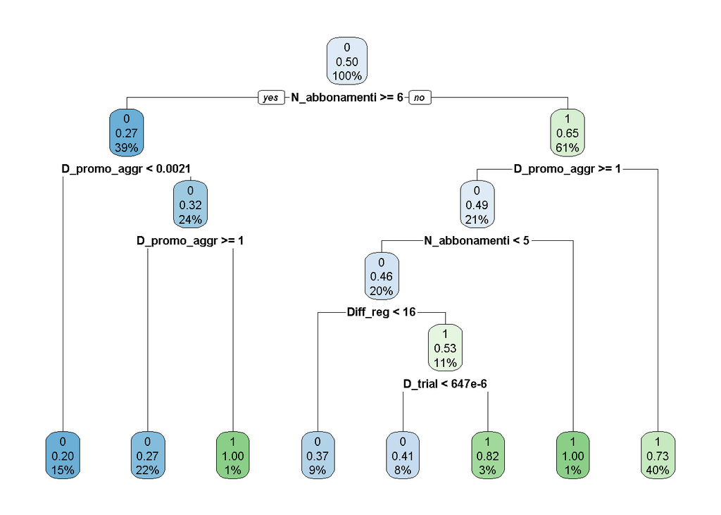

```r
rpart.plot(model_alb)
```

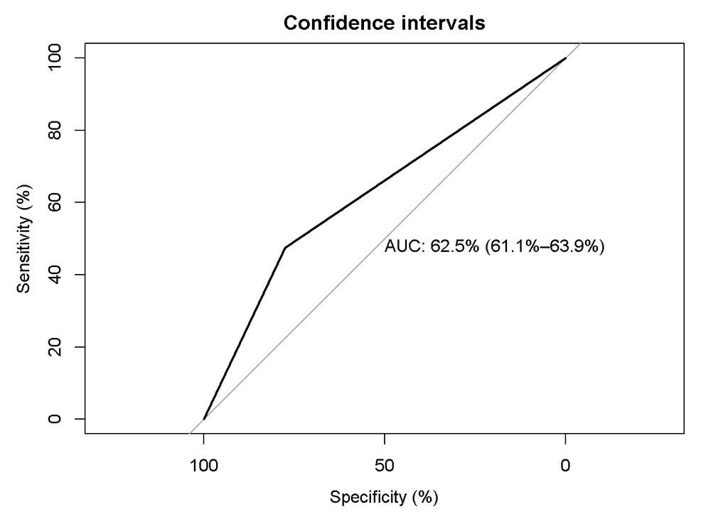

```r
Roc_alb <- plot.roc(df_test_f$is_churn, pred_alb,main="Confidence intervals", percent=TRUE,ci=TRUE, print.auc=TRUE)
```